# Weight Lifting Recognition

Refik Türkeli

6/11/2017

## Introduction

The purpose of this analysis is to recognize common errors that a person does when performing unilateral dumbbell biceps curl. We have a training dataset where subjects were asked to perform the excercise while wearing sensor in 5 different fashions which are recorded in the dataset as `classe` variable. These fashions denote different kinds of errors that are made while performing the exercise. We will be training a model with the sensor data as input and the model will predict the `classe`.

## The Dataset

First lets make some exploratory analysis on the dataset.

```r
dataset <- read.csv("pml-training.csv")
```

The dataset has 160 variables and 19622 observations. Upon inspection, sensors monitor 3 different euler angles: `roll`, `pitch` and `yaw`.

There is also a variable called `user_name` which indicates the person that the sensors record data from. There are 6 unique users and 5 `classe`.

All data points can be summarised in this `user_name` x `classe` table. Count of observations are converted to the percentage of entire dataset.

```r
dataset %>%
  group_by(user_name, classe) %>%
  summarise(count = n()) %>%
  ungroup() %>%
  mutate(count = percent(count / sum(count))) %>%
  spread(classe, count) %>%
  kable()
```

| user_name | A | B | C | D | E |
| --- | --- | --- | --- | --- | --- |
| adelmo | 5.94% | 3.95% | 3.82% | 2.62% | 3.50% |
| carlitos | 4.25% | 3.52% | 2.51% | 2.48% | 3.10% |
| charles | 4.58% | 3.80% | 2.75% | 3.27% | 3.62% |
| eurico | 4.41% | 3.02% | 2.49% | 2.97% | 2.76% |
| jeremy | 6.00% | 2.49% | 3.32% | 2.66% | 2.86% |
| pedro | 3.26% | 2.57% | 2.54% | 2.39% | 2.53% |

Some variables seem to have a lot of `NA` values. These variables are computed based on the sensor data. These variables have statistical abbreviations on their name like `max`, `stddev` and `avg`. The data is a time series data consisting of windows and these computed values exist for the end of windows.

We will use the variables that start with `avg` to explore the relationship of sensor data with the `classe`. There are a lot of variables and `avg` would be a good place to start. Since these data are one per window, we will filter out the missing values.

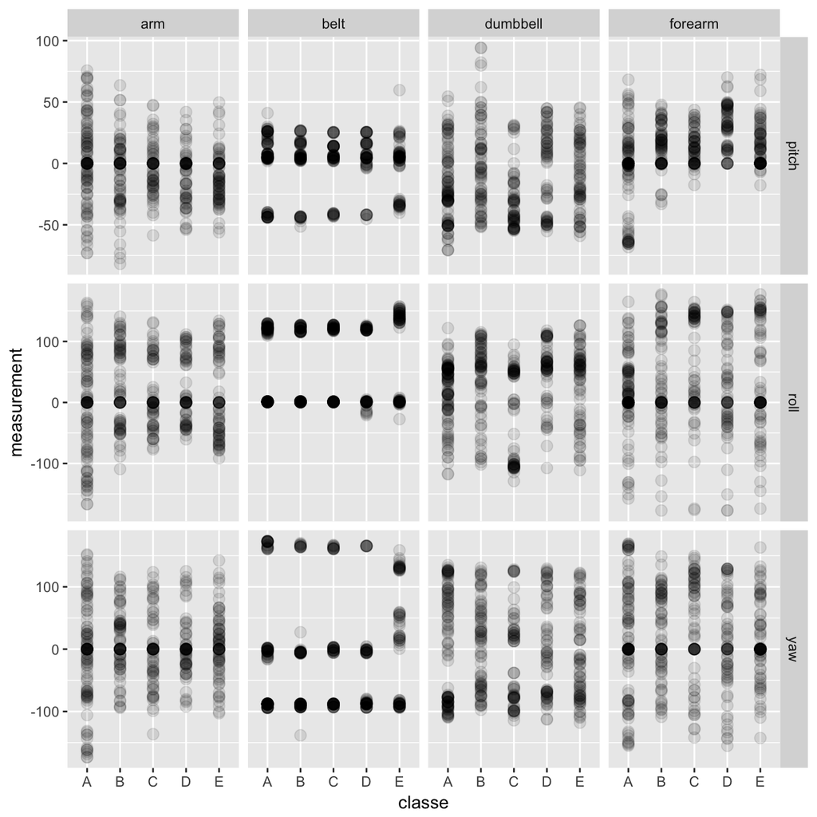

```r
avg_dataset <- dataset %>%
  filter(new_window == "yes") %>%
  select(classe, contains("avg_")) %>%
  gather("colname", "colname_val", contains("avg_")) %>%
  separate("colname", into = c("method", "angle", "sensor")) %>%
  select(-method)

ggplot(avg_dataset, aes(classe, colname_val)) +
  geom_point(alpha = 0.1, size = 3) +
  facet_grid(angle ~ sensor, scales = "free_y") +
  ylab("measurement")
```

## Variable Selection

For the variable selection, we are selecting only features that are not part of a statistics like `mean` or `max`. Those values are once for repetition and mostly `NA`. Our model should be able to work in their absence. Also I’m excluding the `user_name` variable, because the model has to be generic and work for anyone.

```r
cols <- names(dataset)
statistic_abbrev <- c("avg", "stddev", "skewness", "var", "max", "min",
                      "kurtosis", "total", "amplitude")
nonstat_cols <- cols[reduce(map(statistic_abbrev, ~ !grepl(.x, cols)), `&`)]

dataset_nostat <- dataset %>%
  filter(new_window != "yes") %>%
  select_(.dots = nonstat_cols) %>%
  select(-contains("timestamp"), -new_window, -X, -user_name)
```

Making a PCA to determine variables that make up the 80% of the variation in the dataset.

```r
pca_pp <- preProcess(dataset_nostat %>% select(-classe),
                     thresh = 0.8, method = "pca")

pca_pp
```

```
## Created from 19216 samples and 49 variables
##
## Pre-processing:
##   - centered (49)
##   - ignored (0)
##   - principal component signal extraction (49)
##   - scaled (49)
##
## PCA needed 12 components to capture 80 percent of the variance
```

## Partitioning Data

We should partition the before training our model to get a better estimate of our out of sample error rate.

```r
in_train <- createDataPartition(dataset_nostat$classe, p = 0.7, list = FALSE)
training <- dataset_nostat[in_train,]
testing <- dataset_nostat[-in_train,]
```

## Fitting Models

I will start by fitting a decision tree. This model will use k-fold cross validation to improve the fit.

```r
ctree <- train(classe ~ ., data = training, method = "rpart",
               trControl = trainControl(method = "cv"))
ctree
```

```
## CART
##
## 13453 samples
##    49 predictor
##     5 classes: 'A', 'B', 'C', 'D', 'E'
##
## No pre-processing
## Resampling: Cross-Validated (10 fold)
## Summary of sample sizes: 12107, 12108, 12108, 12107, 12108, 12108, ...
## Resampling results across tuning parameters:
##
##   cp          Accuracy   Kappa
##   0.03907305  0.5188459  0.38031559
##   0.05975268  0.4521786  0.26953342
##   0.11275070  0.3227504  0.05802774
##
## Accuracy was used to select the optimal model using  the largest value.
## The final value used for the model was cp = 0.03907305.
```

Accuracy of the classification tree is not great. I will try random forests with bootstrap aggregating error measurement in order to select the best fit.

```r
rf <- train(classe ~ ., data = training, method = "rf",
            trControl = trainControl(method = "oob"))
rf
```

```
## Random Forest
##
## 13453 samples
##    49 predictor
##     5 classes: 'A', 'B', 'C', 'D', 'E'
##
## No pre-processing
## Resampling results across tuning parameters:
##
##   mtry  Accuracy   Kappa
##    2    0.9957630  0.9946399
##   25    0.9973983  0.9967087
##   49    0.9948710  0.9935112
##
## Accuracy was used to select the optimal model using  the largest value.
## The final value used for the model was mtry = 25.
```

Random forests seem to have good accuracy based on cross validation. Now I will apply it once on the test set to get a better estimate for the out of sample error.

```r
predictions <- predict(rf, newdata = testing %>% select(-classe))
confusionMatrix(predictions, testing$classe)
```

```
## Confusion Matrix and Statistics
##
##           Reference
## Prediction    A    B    C    D    E
##          A 1640    2    0    0    0
##          B    0 1112    5    0    0
##          C    0    0 1000    1    0
##          D    0    1    0  943    5
##          E    1    0    0    0 1053
##
## Overall Statistics
##
##                Accuracy : 0.9974
##                  95% CI : (0.9957, 0.9985)
##     No Information Rate : 0.2847
##     P-Value [Acc > NIR] : < 2.2e-16
##
##                   Kappa : 0.9967
##  Mcnemar's Test P-Value : NA
##
## Statistics by Class:
##
##                      Class: A Class: B Class: C Class: D Class: E
## Sensitivity            0.9994   0.9973   0.9950   0.9989   0.9953
## Specificity            0.9995   0.9989   0.9998   0.9988   0.9998
## Pos Pred Value         0.9988   0.9955   0.9990   0.9937   0.9991
## Neg Pred Value         0.9998   0.9994   0.9990   0.9998   0.9989
## Prevalence             0.2847   0.1935   0.1744   0.1638   0.1836
## Detection Rate         0.2846   0.1930   0.1735   0.1636   0.1827
## Detection Prevalence   0.2849   0.1938   0.1737   0.1647   0.1829
## Balanced Accuracy      0.9995   0.9981   0.9974   0.9988   0.9975
```

## Conclusion

Random forest model with the test set prediction indicates similar accuracy to cross validation with 99%. This seems to be a very successful model.